# STAT656: Homework 4

# Introduction

A major issue with antiretroviral drugs is the mutation of the virus’ genes. Because of its high rate of replication ($10^9$ to $10^{10}$ virus per person per day) and error-prone polymerase, HIV can easily develop mutations that alter susceptibility to antiretroviral drugs. The emergence of resistance to one or more antiretroviral drugs is one of the more common reasons for therapeutic failure in the treatment of HIV.

In the paper ‘Genotypic predictors of human immunodeficiency virus type 1 drug resistance’, a sample of in vitro HIV viruses were grown and exposed to a particular antiretroviral therapy. We have a measurement which is the susceptibility of the virus to treatment, in which larger values indicate less susceptible. It has been log transformed. As well, we have whether there is a genetic mutation on each of 208 genes for each virus (each virus is a different row or observation). It is composed of 0’s and 1’s, with a 1 indicating a mutation in a particular gene.

# Problem 1 (10 pts)

```r
load("hiv.rda")

X = hiv.train$x
Y = hiv.train$y

geneLabels = colnames(X)
```

## Problem 1.1

What are n and p in this problem?

#### Answer 1.1.1.

```r
n = nrow(X)
p = ncol(X)
```

The number of observations is **704** and the number of features is **208**.

#### Answer 1.1.2.

What are the features in this problem? What are the observations? What is the supervisor? What do larger values for the supervisor indicate in terms of susceptibility?

**Answer 1.1.2**

**Features (X)**: the 208 binary indicators representing genetic mutations. A value of 1 means a mutation is present, and 0 means it is absent.

**Observations**: Individual HIV virus samples (704 rows). Each row represents a different virus.

**Supervisor (Y)**: The log-transformed susceptibility measurement for the antiretroviral treatment.

**Interpretation**: Larger values of $Y$ indicate greater drug resistance, meaning the virus is less susceptible to treatment.

# Problem 2 (10 pts)

Consider the feature matrix X. Look at the output for the following chunk of code.

```r
table(X)
```

```
## X
##      0      1
## 135589  10843
```

#### Answer 2.1

What do these results indicate?

**Answer 2.1**

```r
mutationCounts = table(X)
totalEntries   = length(X)

zeroCount = unname(mutationCounts["0"])
oneCount = unname(mutationCounts["1"])

zeroPct = 100 * zeroCount / totalEntries
onePct = 100 * oneCount / totalEntries
```

The feature matrix contains **135,589** zeros (**92.6%**) and **10,843** ones (**7.4%**).

Since 0 indicates no mutation and 1 indicates a mutation, the majority of genetic positions across the HIV samples do not have mutations.

The dataset is **highly sparse**, with approximately **92.6%** of its entries equal to zero. A sparse-matrix representation may therefore reduce memory usage.

# Problem 3 (10 pts)

The supervisor is the log transformed susceptibility of a virus to the considered treatment, with large values indicating the virus is relatively more resistant (that is, not susceptible).

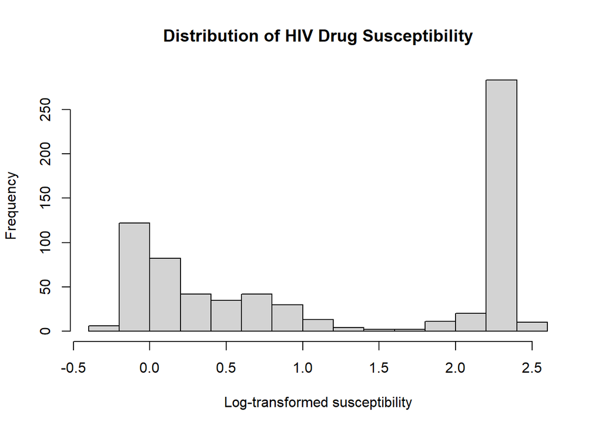

```r
hist(Y,
     main = "Distribution of HIV Drug Susceptibility",
     xlab = "Log-transformed susceptibility",
     ylab = "Frequency")
```

```r
# Summary statistics
yMean = mean(Y)
yMedian = median(Y)
ySd = sd(Y)
yMin = min(Y)
yMax = max(Y)

yQ1 = quantile(Y, 0.25)
yQ3 = quantile(Y, 0.75)

# Calculate sample skewness
ySkewness = mean((Y - yMean)^3) /
              mean((Y - yMean)^2)^(3/2)

# Descriptive summary
summary(Y)
```

```
##     Min.  1st Qu.   Median     Mean  3rd Qu.     Max.
## -0.30103  0.07918  0.98452  1.20748  2.30103  2.47712
```

#### Answer 3.1

What do these results indicate? (Note that even though the supervisor doesn’t look symmetric, we will still apply elastic net to it, as did the authors in that paper I included. We won’t consider further transformations of the supervisor)

**Answer 3.1**

The minimum and maximum equal $\log_{10}(0.5)$ and $\log_{10}(300)$, suggesting a base-10 log and a possible upper assay limit, since many values pile up near the maximum. Larger values indicate greater resistance, so the right-hand cluster represents largely resistant viruses.

Even though the response is bimodal, linear regression does not require the marginal response to be normal. The relevant assumptions concern the conditional relationship and the model errors.

# Problem 4 (70 pts)

We may have (at least) two goals with a data set such as this:

- inference: can we find some genes whose mutation seems to be most related to viral susceptibility?
- prediction: can we make a model that would predict whether this therapy would be efficacious, given a virus with a set of genetic mutations

## Problem 4.1. Inference

Find the estimated coefficient vectors for the following procedures

- lasso
- refitted lasso

### Problem 4.1.1. Lasso

Now, find the CV minimizing lasso solution

#### Answer 4.1.1.

```r
set.seed(656)

# Use the same 10 folds for model comparisons
foldid = sample(rep(1:10, length.out = nrow(X)))

require(glmnet)
lassoOut     = cv.glmnet(X ,Y, alpha=1, standardize = FALSE, foldid = foldid) #Consider why we wouldn't standardize
betaHatLasso = as.vector(coef(lassoOut, s="lambda.min"))
Slasso       = which(betaHatLasso[-1] != 0)

# Summarize results
cat("Optimal lambda:", lassoOut$lambda.min, "\n")
```

```
## Optimal lambda: 0.002690512
```

```r
cat("Number of selected features:", length(Slasso), "\n")
```

```
## Number of selected features: 36
```

```r
cat("Selected genes:", geneLabels[Slasso], "\n")
```

```
## Selected genes: p6 p21 p33 p41 p43 p60 p65 p67 p68 p69 p75 p83 p90 p102 p115 p118 p122 p123 p138 p151 p162 p173 p174 p177 p178 p181 p184 p188 p190 p200 p202 p210 p211 p215 p219 p228
```

```r
# Nonzero lasso coefficients
lassoCoefs = setNames(betaHatLasso, c("(Intercept)", geneLabels))
round(lassoCoefs[lassoCoefs != 0], 4)
```

```
## (Intercept)          p6         p21         p33         p41         p43
##      0.1220      0.0013      0.0139      0.0369      0.0201      0.0152
##         p60         p65         p67         p68         p69         p75
##     -0.0218      0.5985      0.1060      0.0042      0.0644      0.0889
##         p83         p90        p102        p115        p118        p122
##     -0.0320      0.0855      0.0302      0.0944      0.0211     -0.0188
##        p123        p138        p151        p162        p173        p174
##      0.0153      0.0115      0.2178      0.0251     -0.0112     -0.0123
##        p177        p178        p181        p184        p188        p190
##     -0.0050      0.0035      0.0307      1.8803      0.0144      0.0265
##        p200        p202        p210        p211        p215        p219
##     -0.0298     -0.0090      0.0410      0.0150      0.1837      0.0178
##        p228
##      0.0251
```

We do not standardize because every feature is a 0/1 mutation indicator, so all features are already on the same scale. Standardizing would divide each column by its SD; rare mutations have small SDs, so their coefficients would effectively be penalized less. Leaving them unstandardized keeps the penalty equal across mutations.

The Lasso model was fitted using cross-validation to select the penalty parameter that minimizes estimated prediction error. The optimal penalty parameter is **0.002691**. At this value, Lasso selected **36** out of **208** mutation features with nonzero coefficients. The remaining **172** feature coefficients were shrunk to zero.

### Problem 4.1.2. Refitted lasso

Now, find the refitted lasso using the ‘1 standard error rule’ lambda and refitting with least squares. I’ve included a plot of CV so that you can see the lambda.1se solution.

#### Answer 4.1.2.

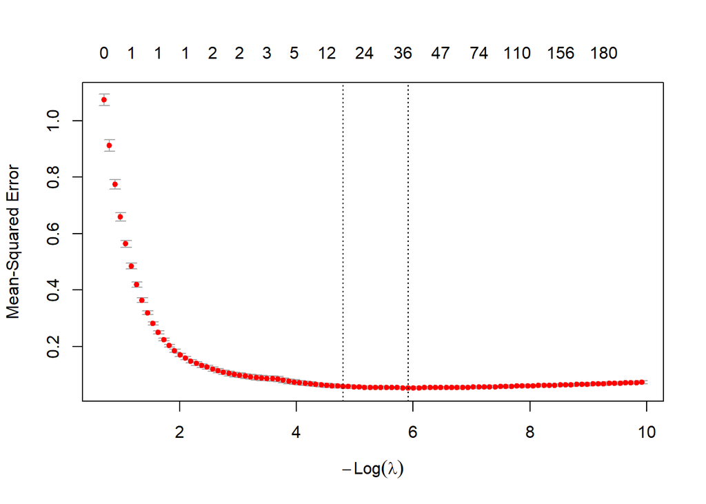

```r
plot(lassoOut)
```

```r
betaHatTemp     = as.vector(coef(lassoOut, s="lambda.1se"))
Srefitted       = which(betaHatTemp[-1] != 0)
Xdf             = as.data.frame(X[,Srefitted, drop=FALSE])
refittedOut     = lm(Y ~ ., data=Xdf)
betaHatRefitted = coef(refittedOut)
```

```r
cat("Lambda (1-SE):", lassoOut$lambda.1se, "\n")
```

```
## Lambda (1-SE): 0.008216435
```

```r
cat("Features selected:", length(Srefitted), "\n")
```

```
## Features selected: 16
```

```r
cat("Features excluded:", ncol(X) - length(Srefitted), "\n")
```

```
## Features excluded: 192
```

```r
# Display refitted regression coefficients
print(betaHatRefitted)
```

```
## (Intercept)         p21         p41         p65         p67         p69
##  0.09857841  0.06585942  0.01407802  0.66636702  0.10217962  0.07058462
##         p75        p118        p151        p162        p181        p184
##  0.11712646  0.02704918  0.31028150  0.04527725  0.05544007  1.89152262
##        p200        p210        p215        p219        p228
## -0.04322196  0.05059270  0.19717664  0.02808258  0.02857999
```

Using the one-standard-error rule, the selected penalty parameter is **0.008216**. The Lasso model selected **16** out of **208** mutation features. These selected features were then refitted using ordinary least squares without the Lasso penalty. This approach separates variable selection from coefficient estimation, allowing the selected coefficients to be re-estimated without Lasso shrinkage.

#### Answer 4.1.3

What are the genes selected by the refitted lasso (that is, what are the ‘geneLabels’ (the feature names) that correspond to the nonzero coefficients in the coefficient vector)?

```r
selectedGenes = geneLabels[Srefitted]

cat('The selected genes from refitted lasso are: \n',
     paste(selectedGenes, collapse = ", "),'\n')
```

```
## The selected genes from refitted lasso are:
##  p21, p41, p65, p67, p69, p75, p118, p151, p162, p181, p184, p200, p210, p215, p219, p228
```

**Answer 4.1.3**

The Refitted Lasso selected **16** mutation features using the one-standard-error rule. The selected genes are: **p21, p41, p65, p67, p69, p75, p118, p151, p162, p181, p184, p200, p210, p215, p219, p228**. These features were subsequently used in an ordinary least squares regression to obtain the refitted coefficients.

### Problem 4.1.4

For the refitted lasso, which gene is associated with the largest DECREASE in viral susceptibility (note: remember how the supervisor is coded) to this particular drug?

#### Answer 4.1.4

```r
# Exclude the intercept
geneCoefficients = betaHatRefitted[-1]

# Find the largest positive coefficient
largestIndex = which.max(geneCoefficients)

# Extract gene and coefficient
largestGene = names(geneCoefficients)[largestIndex]
largestCoefficient = unname(geneCoefficients[largestIndex])

cat("Gene associated with the largest decrease in susceptibility:",
    largestGene, "\n")
```

```
## Gene associated with the largest decrease in susceptibility: p184
```

```r
cat("Estimated coefficient:",
    largestCoefficient, "\n")
```

```
## Estimated coefficient: 1.891523
```

**Answer 4.1.4**

Based on the Refitted Lasso model, the gene associated with the largest decrease in viral susceptibility is **p184**, with an estimated regression coefficient of **1.8915**.

This gene has the largest positive coefficient among the selected predictors, indicating the strongest estimated increase in the log-transformed resistance response when the mutation is present, holding other selected mutations constant.

#### Answer 4.1.5

Interpret this estimated coefficient within the context of the problem

**Answer 4.1.5**

A change from no mutation to mutation at gene **p184** is associated with an estimated increase of **1.8915** units in the log-transformed drug resistance response, holding all other selected mutations constant.

Because the response appears to be on the base-10 log scale, a virus with the **p184** mutation is estimated to be about $10^{1.89} \approx$ **78-fold** more resistant than an otherwise identical virus without it.

Since higher response values indicate greater drug resistance, this mutation is associated with decreased viral susceptibility to the treatment.

## Problem 4.2. Prediction

Now, let’s look at some predictions made by these methods. Use the following for the test set:

```r
Xtest = hiv.test$x
Ytest = hiv.test$y
```

Let’s compute the test error (that is the loss evaluated on this test data)

- ridge
- lasso
- refitted lasso

We can get the predictions out via various ‘predict’ functions

### Problem 4.2.1. Ridge regression at lambda.min

Now that we are looking at prediction, we can use ridge regression (which mainly is used for prediction). Using the package glmnet, let’s plot the CV curve over the grid of lambda values and indicate the minimum, and finally report the CV estimate of the test error for ridge at each lambda.

There is no need to report the p coefficient estimates from the ridge solution. Also, glmnet has a grid problem. The automatically allocated grid by glmnet has a minimum value that is too small and hence we get a `boundary’ solution. Let’s make two plots, one that shows the CV plot with and one without this boundary issue

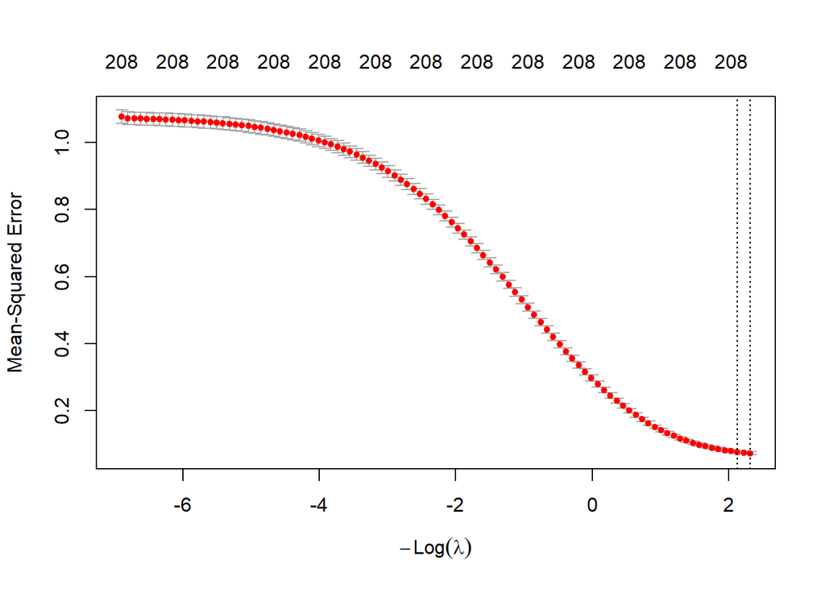

```r
ridgeOut = cv.glmnet(X,Y,alpha=0, foldid = foldid)
plot(ridgeOut) #This has the boundary issue
```

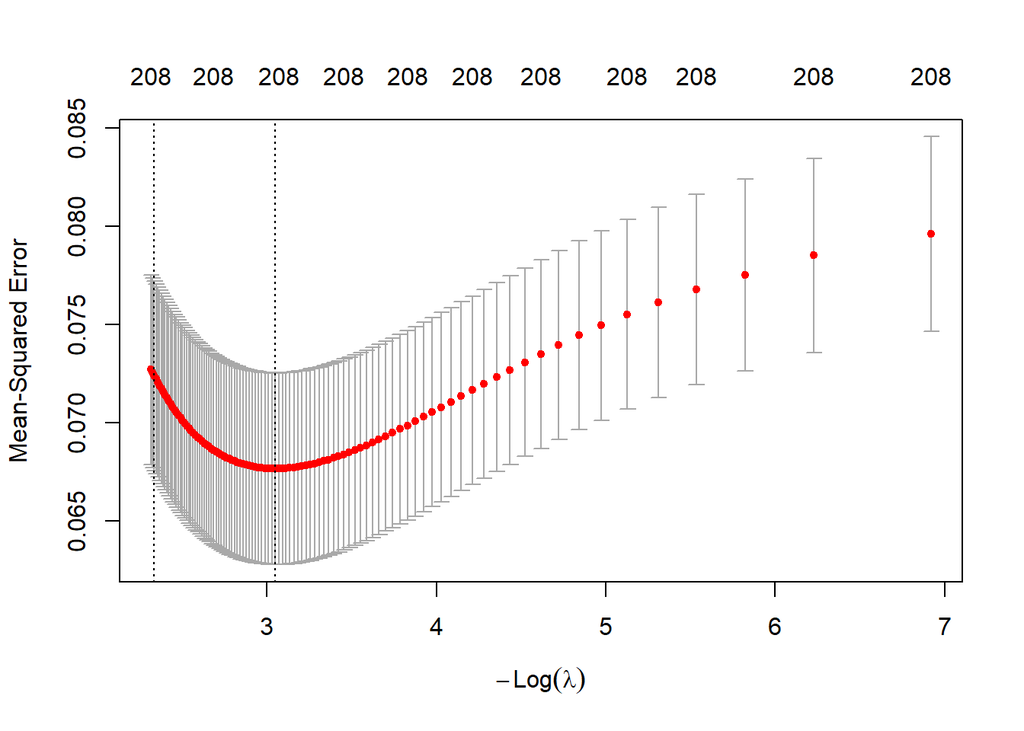

```r
minLambda = min(ridgeOut$lambda)
lambdaNew = seq(minLambda, minLambda*0.01,length=100)
ridgeOut  = cv.glmnet(x = X, y = Y, alpha = 0,lambda = lambdaNew, foldid = foldid)
plot(ridgeOut)
```

```r
YhatTestRidge = predict(ridgeOut, Xtest, s = 'lambda.min')
```

#### Answer 4.2.1.

Why is a boundary solution for minimizing CV an issue?

**Answer 4.2.1**

A boundary solution occurs when the minimum cross-validation error is found at the edge of the tested lambda grid. This is problematic because the optimal lambda may lie outside the original search range, so we cannot be certain that the minimum CV error has been identified.

To address this, we extended the lambda grid toward smaller values and repeated cross-validation.

The selected penalty parameter from the revised grid is **0.04745**.

```r
# grid range
range(ridgeOut$lambda)
```

```
## [1] 0.0009884851 0.0988485077
```

lambda.min (**0.04745**) now lies strictly inside the grid, so the boundary issue is resolved.

### Problem 4.2.2. Lasso

We can use the previously computed lasso object to get the predictions

```r
YhatTestLasso = predict(
  lassoOut,
  newx = Xtest,
  s = "lambda.min"
)
```

#### Answer 4.2.3. Refitted lasso

Get the predictions for the refitted lasso. Remember, choose lambda via the 1se rule and then fit the least squares solution on the selected features.

```r
XtestDF = as.data.frame(
  Xtest[, Srefitted, drop = FALSE]
)

YhatTestRefitted = predict(
  refittedOut,
  newdata = XtestDF
)
```

#### Answer 4.2.4. Getting the test errors

```r
# Get the test error
testErrorRidge    = mean((Ytest - as.vector(YhatTestRidge))^2)
testErrorLasso    = mean((Ytest - as.vector(YhatTestLasso))^2)
testErrorRefitted = mean((Ytest - as.vector(YhatTestRefitted))^2)

# Compare all models
modelComparison = data.frame(
  Model = c("Ridge", "Lasso", "Refitted Lasso"),
  Test_MSE = c(
    testErrorRidge,
    testErrorLasso,
    testErrorRefitted
  )
)

modelComparison = modelComparison[
  order(modelComparison$Test_MSE),
]

knitr::kable(
  modelComparison,
  digits = 5,
  row.names = FALSE,
  caption = "Test MSE comparison"
)
```

Test MSE comparison

| Model | Test_MSE |
| --- | --- |
| Lasso | 0.06520 |
| Refitted Lasso | 0.06927 |
| Ridge | 0.09716 |

```r
bestModel = modelComparison$Model[1]
bestMSE = modelComparison$Test_MSE[1]
```

- The test error from ridge w/ lambda chosen as lambda.min is **0.0972**
- The test error from lasso w/ lambda chosen as lambda.min is **0.0652**
- The test error from refitted lasso is **0.0693**

Among the three methods, **Lasso** achieves the lowest test MSE of **0.0652**, although performance may vary on other samples.

The refitted lasso uses only **16** mutations versus **36** for the lasso, yet its test MSE is only slightly higher. It trades very little accuracy for a much simpler model. Both sparse methods beat ridge, which suggests resistance is driven by a small number of mutations.